# Jasmine O’Neal Unit1_HW

Jasmine O’Neal

2023-01-04

## Exercise 1: Air Pollution Study

Researchers wish to assess whether air pollution has a negative impact on well populated cities by investigating the cities mortality rates (per 100,000). It is generally accepted that mortality rates depend on a a number of factors including socioeconomic and environmental variables.

To assess whether air pollution has an effect on the mortality rate, we wish to determine whether measurements of pollutants such as nitrogen oxides and sulfur dioxide have an effect after accounting for well-known factors. The following code chunk loads in the data set and provides an overall summary graph. Precipitation is mean rainfall in inches. Education is median number of school years completed among adults and nonwhite is the percentage of the cities population that is nonwhite.

```r
#load libraries
#load in the data set and provide an overall summary graph
library(Sleuth3)
library(GGally)
air<-ex1123
head(air)
```

```
##              City   Mort Precip Educ NonWhite NOX SO2
## 1    San Jose, CA 790.73     13 12.2      3.0  32   3
## 2     Wichita, KS 823.76     28 12.1      7.5   2   1
## 3   San Diego, CA 839.71     10 12.1      5.9  66  20
## 4   Lancaster, PA 844.05     43  9.5      2.9   7  32
## 5 Minneapolis, MN 857.62     25 12.1      2.0  11  26
## 6      Dallas, TX 860.10     35 11.8     14.8   1   1
```

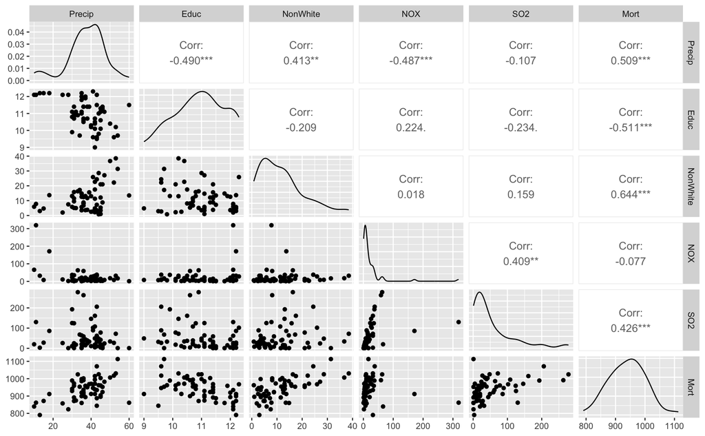

```r
ggpairs(air[,c(3:7,2)])
```

# A. Using the graph, provide commentary on what trends you see with the predictors and the mortality rate. Do any of them look nonlinear?

### Trends:

1. The higher educated seem to have lesser mortality
2. Precipitation and mortality seems to be mostly linear
3. NOX and SO2 with respect to mortality appears non-linear
4. the higher the percentage of NonWhite mortality increases

# B. Fit a regression model using all five predictors. Provide the residual diagnostics and comment on whether the assumptions look reasonable.

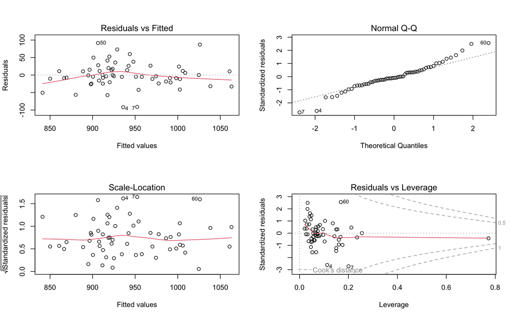

```r
# mortality regression model
airmodel<-lm(Mort ~ Precip + Educ + NonWhite + NOX + SO2, data = air)
# diagnostic plots
par(mfrow=c(2,2))
plot(airmodel)
```

```r
par(mfrow=c(1,1))
```

# C. Use the `vif` function within the **car** package to examine the VIFs. Are there any concerns for this particular study’s goals and research question? What if there were really high VIFs among Education, Nonwhite, and NOX? Would that change your answer?

```r
# load car package
library(car)
# examine VIFs
vif(airmodel)
```

```
##   Precip     Educ NonWhite      NOX      SO2
## 2.064568 1.509714 1.329690 1.675305 1.418590
```

### Discuss VIFs Output:

1. The independent variables that are being considered in this model have a VIF score under 5 which indicates no issues for multicollinearity
2. The study’s goals is to understand if NOX and SO2 have an effect after accounting for well-known factors. Since there’s no strong relationship between these variables, the model can evaluate the significance of each variable in understanding if air pollution has an effect on mortality rate
3. If there’s really high VIFs among Education, Nonwhite, and NOX then would need to understand the relationship between these variables to see if any can be eliminated for duplicate purposes or some other negative impact on the model that could effect results

# D. Assuming the assumptions of this model are reasonable, what can generally be said about the association of the pollution variables with mortality? Directly interpret the regression coefficient

```r
# summary
summary(airmodel)
```

```
##
## Call:
## lm(formula = Mort ~ Precip + Educ + NonWhite + NOX + SO2, data = air)
##
## Residuals:
##     Min      1Q  Median      3Q     Max
## -91.893 -18.986  -3.433  15.872  91.528
##
## Coefficients:
##              Estimate Std. Error t value Pr(>|t|)
## (Intercept) 1000.1026    92.3982  10.824 3.85e-15 ***
## Precip         1.3792     0.7000   1.970 0.053943 .
## Educ         -15.0791     7.0706  -2.133 0.037518 *
## NonWhite       3.1602     0.6287   5.026 5.84e-06 ***
## NOX           -0.1076     0.1359  -0.792 0.432030
## SO2            0.3554     0.0914   3.889 0.000278 ***
## ---
## Signif. codes:  0 '***' 0.001 '**' 0.01 '*' 0.05 '.' 0.1 ' ' 1
##
## Residual standard error: 37.36 on 54 degrees of freedom
## Multiple R-squared:  0.6698, Adjusted R-squared:  0.6392
## F-statistic:  21.9 on 5 and 54 DF,  p-value: 6.478e-12
```

### Describe Association of Pollution Variables with Mortality:

1. Since NOX has a p-value greater than .05, it’s not statistically significant enough to impact mortality
2. For each 1 unit increase in SO2, the estimated/predicted mortality rate increases 0.36 units

# E. The interested student might wonder whether a potentially better fit to the data set may be modeling NOX and SO2 on the log scale. The graphs below highlight the basic differences. Update your previous model and comment on whether the general conclusion would change or not. Directly interpret the regression coefficient on the $SO_2$ variable now

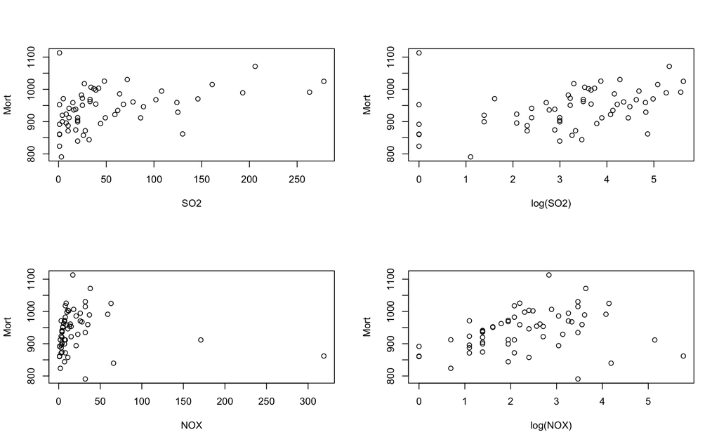

```
##
## Call:
## lm(formula = Mort ~ Precip + Educ + NonWhite + log(NOX) + log(SO2),
##     data = air)
##
## Residuals:
##      Min       1Q   Median       3Q      Max
## -102.222  -19.547    0.239   20.084   95.386
##
## Coefficients:
##             Estimate Std. Error t value Pr(>|t|)
## (Intercept) 940.6584    94.0551  10.001 6.81e-14 ***
## Precip        1.9467     0.7007   2.778   0.0075 **
## Educ        -14.6645     6.9379  -2.114   0.0392 *
## NonWhite      3.0289     0.6685   4.531 3.29e-05 ***
## log(NOX)      6.7164     7.3990   0.908   0.3680
## log(SO2)     11.3578     5.2955   2.145   0.0365 *
## ---
## Signif. codes:  0 '***' 0.001 '**' 0.01 '*' 0.05 '.' 0.1 ' ' 1
##
## Residual standard error: 36.3 on 54 degrees of freedom
## Multiple R-squared:  0.6883, Adjusted R-squared:  0.6594
## F-statistic: 23.85 on 5 and 54 DF,  p-value: 1.418e-12
```

## Exercise 2: Predicting Fish Weights

A quick exploration between the relationships between log(weight) and Length1 for the different species suggests that they potentially have different slopes.

```r
# read fish file
# plot data
fish<-read.csv("Fish.csv",header=T,stringsAsFactors = T)
summary(fish)
```

```
##   Species       Weight           Length1         Length2         Length3
##  Perch:56   Min.   :   5.90   Min.   : 7.50   Min.   : 8.40   Min.   : 8.80
##  Pike :17   1st Qu.:  90.25   1st Qu.:18.20   1st Qu.:19.85   1st Qu.:21.45
##  Roach:19   Median : 175.00   Median :22.00   Median :24.00   Median :26.35
##  Smelt:14   Mean   : 347.37   Mean   :25.61   Mean   :27.61   Mean   :29.65
##             3rd Qu.: 513.00   3rd Qu.:34.58   3rd Qu.:37.00   3rd Qu.:39.38
##             Max.   :1650.00   Max.   :59.00   Max.   :63.40   Max.   :68.00
##      Height           Width
##  Min.   : 1.728   Min.   :1.048
##  1st Qu.: 5.534   1st Qu.:3.205
##  Median : 6.495   Median :3.823
##  Mean   : 6.884   Mean   :4.158
##  3rd Qu.: 8.507   3rd Qu.:5.135
##  Max.   :12.800   Max.   :8.142
```

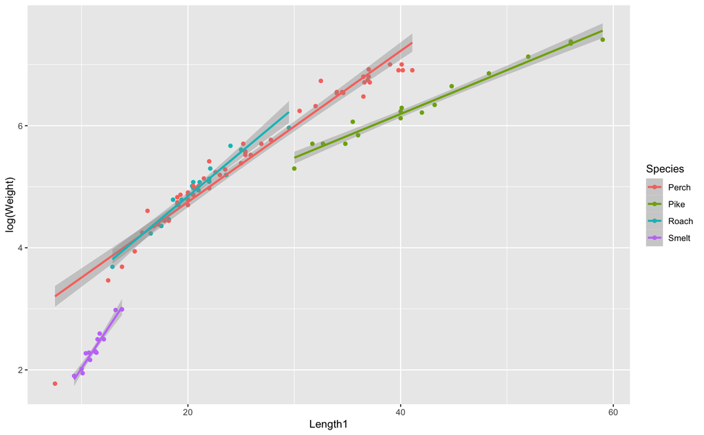

```r
library(ggplot2)
ggplot(fish,aes(x=Length1,y=log(Weight),color=Species))+geom_point()+geom_smooth(method="lm")
```

# A. Fit a model so that individual intercepts and slopes are fitted for each species. Use the contrast framework to estimate the slope for the Smelt species. Provide a formal interpretation of this slope and include a 95 percent confidence interval. You do not need to provide a formal interpretation of the interval, just the slope value (point estimate).

```r
# fish regression model
fishmodel = lm(log(Weight) ~ Length1 * Species, data = fish)
summary(fishmodel)
```

```
##
## Call:
## lm(formula = log(Weight) ~ Length1 * Species, data = fish)
##
## Residuals:
##      Min       1Q   Median       3Q      Max
## -1.42900 -0.08097  0.03575  0.10868  0.43677
##
## Coefficients:
##                       Estimate Std. Error t value Pr(>|t|)
## (Intercept)           2.276152   0.091656  24.834  < 2e-16 ***
## Length1               0.123707   0.003382  36.574  < 2e-16 ***
## SpeciesPike           1.044957   0.273696   3.818 0.000236 ***
## SpeciesRoach         -0.339018   0.314780  -1.077 0.284125
## SpeciesSmelt         -2.883465   0.561749  -5.133 1.45e-06 ***
## Length1:SpeciesPike  -0.051934   0.006841  -7.592 1.87e-11 ***
## Length1:SpeciesRoach  0.021607   0.014724   1.468 0.145441
## Length1:SpeciesSmelt  0.139809   0.049085   2.848 0.005356 **
## ---
## Signif. codes:  0 '***' 0.001 '**' 0.01 '*' 0.05 '.' 0.1 ' ' 1
##
## Residual standard error: 0.2148 on 98 degrees of freedom
## Multiple R-squared:  0.9794, Adjusted R-squared:  0.9779
## F-statistic: 665.2 on 7 and 98 DF,  p-value: < 2.2e-16
```

```r
# contrast maker
lm.contrast<-function(lmobj,contrast){
  if(is.matrix(contrast)==F) contrast<-matrix(contrast,nrow=1)
  if(ncol(contrast)!=length(coef(lmobj))) return("Error: Contrast length does not match the number of coefficients in linear model object.")
  estimates<-contrast %*% coef(lmobj)
  se<- sqrt(diag(contrast %*% vcov(lmobj) %*% t(contrast)))
  t.stat<-estimates/se
  p.val<-pt(-abs(t.stat),df=lmobj$df.residual)
  ci.l<-estimates-qt(.975,df=lmobj$df.residual)*se
  ci.u<-estimates+qt(.975,df=lmobj$df.residual)*se
  results<-data.frame(Estimates=estimates,SE=se,t.stat,p.val,Lower=ci.l,Upper=ci.u)
  return(results)
  }

# Smelt contrast:
smeltcontrast = c(0,1,0,0,0,0,0,1)
contrast.matrix<-rbind(smeltcontrast)
lm.contrast(fishmodel,contrast.matrix)
```

```
##               Estimates         SE   t.stat        p.val     Lower     Upper
## smeltcontrast 0.2635158 0.04896814 5.381374 2.523607e-07 0.1663402 0.3606915
```

# B. (Stretch question) Suppose I wanted to formally test if the slope for the pike species is different from the slope of the smelt. What contrast could we construct to formally test this? Hint: Determine the beta’s that are involved in each one of the indviduals slopes and subtract one from the other.

```r
mymodel<-lm(log(Weight)~Length1*Species,data=fish)
summary(mymodel)
```

```
##
## Call:
## lm(formula = log(Weight) ~ Length1 * Species, data = fish)
##
## Residuals:
##      Min       1Q   Median       3Q      Max
## -1.42900 -0.08097  0.03575  0.10868  0.43677
##
## Coefficients:
##                       Estimate Std. Error t value Pr(>|t|)
## (Intercept)           2.276152   0.091656  24.834  < 2e-16 ***
## Length1               0.123707   0.003382  36.574  < 2e-16 ***
## SpeciesPike           1.044957   0.273696   3.818 0.000236 ***
## SpeciesRoach         -0.339018   0.314780  -1.077 0.284125
## SpeciesSmelt         -2.883465   0.561749  -5.133 1.45e-06 ***
## Length1:SpeciesPike  -0.051934   0.006841  -7.592 1.87e-11 ***
## Length1:SpeciesRoach  0.021607   0.014724   1.468 0.145441
## Length1:SpeciesSmelt  0.139809   0.049085   2.848 0.005356 **
## ---
## Signif. codes:  0 '***' 0.001 '**' 0.01 '*' 0.05 '.' 0.1 ' ' 1
##
## Residual standard error: 0.2148 on 98 degrees of freedom
## Multiple R-squared:  0.9794, Adjusted R-squared:  0.9779
## F-statistic: 665.2 on 7 and 98 DF,  p-value: < 2.2e-16
```

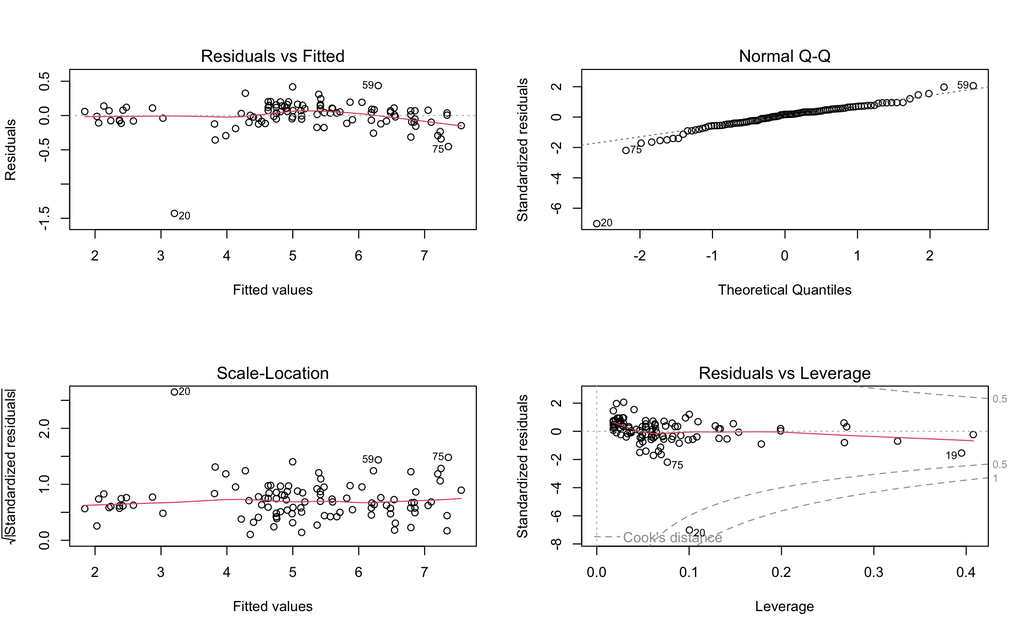

```r
par(mfrow=c(2,2))
plot(mymodel)
```

```r
# pike and smelt contrast
pikecontrast = c(0,1,0,0,0,1,0,0)
smeltcontrast = c(0,1,0,0,0,0,0,1)
contrast.matrix<-rbind(smeltcontrast, pikecontrast)
lm.contrast(fishmodel,contrast.matrix)
```

```
##                Estimates          SE    t.stat        p.val      Lower
## smeltcontrast 0.26351585 0.048968137  5.381374 2.523607e-07 0.16634017
## pikecontrast  0.07177348 0.005946313 12.070248 2.127993e-21 0.05997321
##                    Upper
## smeltcontrast 0.36069152
## pikecontrast  0.08357374
```

### Difference In Slope Between Pike and Smelt Species

1. There is a difference in slope of -0.191743

## Exercise 3

The following code simulates a data set that follows a trend that is a 4th degree polynomial. Below is a plot of the data along with residual plots from regression model.

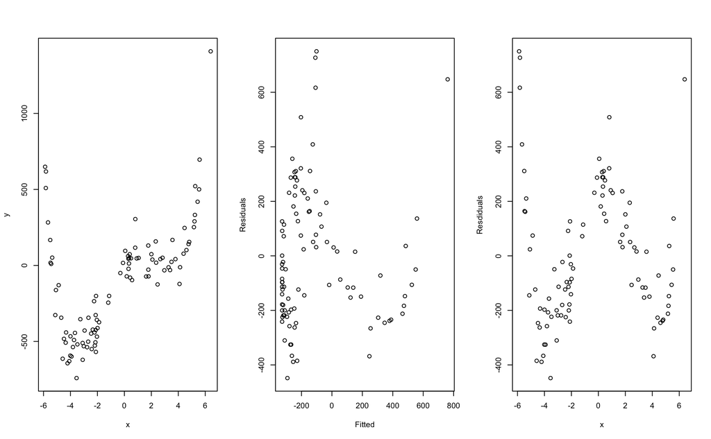

```r
set.seed(1234)
x<-runif(100,-6,6.5)
trend<- 2*x^4-2*x^3-50*x^2+100*x+2
y<-trend+rnorm(100,0,100)
mymodel<-lm(y~poly(x,2))

par(mfrow=c(1,3))
plot(x,y)
plot(mymodel$fitted.values,mymodel$residuals,ylab="Residuals",xlab="Fitted")
plot(x,mymodel$residuals,ylab="Resdiduals")
```

```r
par(mfrow=c(1,1))
```

# A. Using the graphics, explain to a layman why the current model being fitted is not a good fit to the data set.

1. The residuals plot displays a trend which indicates the model needs to be adjusted so that the data points are randomly scattered around zero. When appropriately adjusted the output from the model will be more accurate.

# B. To help the laymen better understand, repeat the graphics using different polynomial fits to illustrate what a better model fit would look.

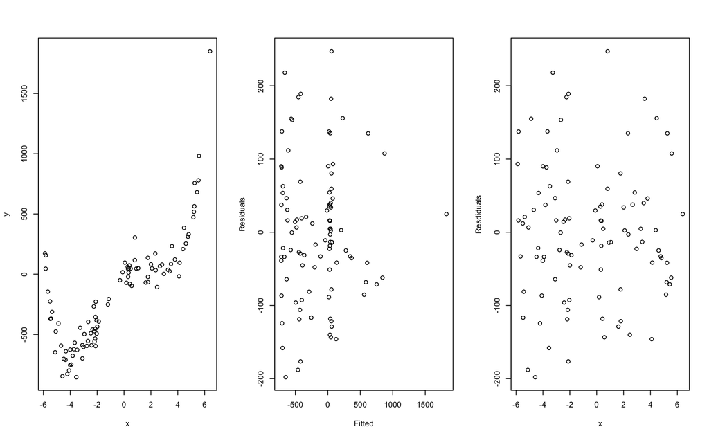

```r
#different polynomial fits
set.seed(1234)
x<-runif(100,-6,6.5)
trend<- 2*x^4-2*x^2-50*x^2+100*x+2
y<-trend+rnorm(100,0,100)
mymodel<-lm(y~poly(x,4))

par(mfrow=c(1,3))
plot(x,y)
plot(mymodel$fitted.values,mymodel$residuals,ylab="Residuals",xlab="Fitted")
plot(x,mymodel$residuals,ylab="Resdiduals")
```

```r
par(mfrow=c(1,1))
```